# text mining

WAMG

2018年3月1日

# 1. R 爬蟲抓資料

首先利用網路爬蟲抓取資料:

[figure not shown]

[figure not shown]

```r
library(rvest)
g.url <- "http://www.millionbook.net/wx/j/jingyong/sdxl/001.htm"

a <- read_html(g.url)

#抓取特定網頁格式資料
#配和 selectorgadget chorm應用程式
b  <- html_nodes(a,".tt2")
#讀取裡面的文字
d  <- html_text(b)
substr(d,1,200)
```

```
## [1] "第一回　風月無情\r\n\r\n　　「越女採蓮秋水畔，窄袖輕羅，暗露雙金釧。照影摘花花似面，芳心只共絲爭亂。\r\n\r\n　　雞尺溪頭風浪晚，霧重煙輕，不見來時伴。隱隱歌聲歸桌遠，離愁引著江南岸。」\r\n\r\n　　一陣輕柔婉轉的歌聲，飄在煙水濛濛的湖面上。歌聲發自一艘小船之中，船裡五個少女和歌嘻笑，盪舟採蓮。她們唱的曲子是北宋大詞人歐陽修所作的「蝶戀花」詞，寫的正是越女蓮的情景，雖只寥六十字，但季節、時辰、所在、景"
```

```r
#清理網頁中特定符號
d1 <- gsub("\r\n","",d)
d1 <- gsub(pattern = "\\（[１-９]\\）","",d1)
#把標題及內文分開
t1 <- gsub("　　","",substr(d1,1,10))
t2 <- gsub("　　","",substr(d1,11,nchar(d1)))
t1; substr(t2,1,100)
```

```
## [1] "第一回　風月無情"
```

```
## [1] "「越女採蓮秋水畔，窄袖輕羅，暗露雙金釧。照影摘花花似面，芳心只共絲爭亂。雞尺溪頭風浪晚，霧重煙輕，不見來時伴。隱隱歌聲歸桌遠，離愁引著江南岸。」一陣輕柔婉轉的歌聲，飄在煙水濛濛的湖面上。歌聲發自一艘小"
```

利用 for 迴圈收集全部章節資料

```r
G_E_C <- list()

for(i in 1:40){
#自動換頁
if(i < 10){
page <- paste0("00",i)
}else{
  page <- paste0("0",i)
}
g.url <- paste0("http://www.millionbook.net/wx/j/jingyong/sdxl/",page,".htm")

a <- read_html(g.url)

#抓取特定網頁格式資料
b  <- html_nodes(a,".tt2")
#讀取裡面的文字
d  <- html_text(b)
#清理網頁中特定符號
d1 <- gsub("\r\n","",d)
d1 <- gsub(pattern = "\\（[１-９]\\）","",d1)
#把標題及內文分開
t1 <- gsub("　　","",substr(d1,1,10))
t2 <- gsub("　　","",substr(d1,11,nchar(d1)))


#儲存資料
G_E_C[[i]] <- c(t1,t2)
Sys.sleep(1)
}

G_E_C <- do.call(rbind,G_E_C)
colnames(G_E_C) <- c("title","content")
write.csv(G_E_C,"C:\\Users\\biostat1142\\Desktop\\text mining\\G_E_C.csv",row.names = F)
```

# 2.斷詞及 tf_idf

## 斷詞(jiebaR)

收集完資料後，首先需要斷詞，可以利用jiebaR 這個package 幫助我們完成斷詞動作。

```r
rm(list=ls())
library(jiebaR)
#設定斷詞工具
my.text <- worker(user="C:\\Users\\biostat1142\\Documents\\R\\win-library\\3.4\\jiebaRD\\dict\\g_e_c.dict.utf8")
my.text
```

```
## Worker Type:  Jieba Segment
##
## Default Method  :  mix
## Detect Encoding :  TRUE
## Default Encoding:  UTF-8
## Keep Symbols    :  FALSE
## Output Path     :
## Write File      :  TRUE
## By Lines        :  FALSE
## Max Word Length :  20
## Max Read Lines  :  1e+05
##
## Fixed Model Components:
##
## $dict
## [1] "C:/Users/biostat1142/Documents/R/win-library/3.4/jiebaRD/dict/jieba.dict.utf8"
##
## $user
## [1] "C:\\Users\\biostat1142\\Documents\\R\\win-library\\3.4\\jiebaRD\\dict\\g_e_c.dict.utf8"
##
## $hmm
## [1] "C:/Users/biostat1142/Documents/R/win-library/3.4/jiebaRD/dict/hmm_model.utf8"
##
## $stop_word
## NULL
##
## $user_weight
## [1] "max"
##
## $timestamp
## [1] 1522374797
##
## $default $detect $encoding $symbol $output $write $lines $bylines can be reset.
```

1. user 為自訂詞庫，當發現斷詞斷不好時，就需要增加詞庫，幫助我們正常斷詞。
2. stop_word 為停止詞，例如，“的”，“了”，等等…，無意義的詞就可以放進去，在斷詞時就可以刪除掉。

```r
data1 <- read.csv("C:\\Users\\biostat1142\\Desktop\\text mining\\G_E_C.csv",stringsAsFactors=F)
text1 <- my.text[data1[1,2]]
text1[1:10]
```

```
##  [1] "越"     "女"     "採"     "蓮"     "秋水"   "畔"     "窄袖"
##  [8] "輕羅"   "暗露"   "雙金釧"
```

## tf_idf

tf(term frequency,詞頻) : 某一詞語出現次數除以該文章的總詞語數，例如一篇文章種詞語數為100，而詞語“我” 出現3次，則“我”這個詞的詞頻為3/100。\

idf(inverse document frequency,逆向檔案頻率) : 例如:“我”這個詞出現在1,000份檔案中，而總檔案數為10,000，則“我”這個詞的idf 值為log(10,000/1,000)=1。 從公式上我們就可以發現，當這個詞在更多文章中出現，idf 值會越小。

tf_idf = tf*idf : tf_idf 傾向於過濾掉常見的詞語，保留重要的詞語。

因此我們可以利用 tf_idf 找出文章中，特有的詞語。

```r
G_E_C <- list()
for(r in 1:40){
  #章節名稱
  chapter <- data1[r,1]
  #斷詞結果
  word   <- my.text[data1[r,2]]
  #算各個單詞出現次數
  word_2 <- freq(word)
  G_E_C[[r]] <- data.frame(chapter,word_2$char,word_2$freq)
}

G_E_C <- do.call(rbind,G_E_C)
colnames(G_E_C) <- c("chapter","word","n")

G_E_C[1:10,]
```

```
##             chapter word n
## 1  第一回　風月無情 尋思 1
## 2  第一回　風月無情 分別 1
## 3  第一回　風月無情 逼將 1
## 4  第一回　風月無情 已裹 1
## 5  第一回　風月無情 黑煙 1
## 6  第一回　風月無情 調勻 1
## 7  第一回　風月無情 急喘 1
## 8  第一回　風月無情 難言 1
## 9  第一回　風月無情 悶惡 1
## 10 第一回　風月無情 還生 1
```

```r
library(tidytext) #幫忙算tf_idf 值
library(ggplot2)
library(ggpubr)
#bind_tf_idf(幫我們算tf_idf 值)
G_E_C_word <- bind_tf_idf(G_E_C,word,chapter,n)
G_E_C_word[1:10,]
```

```
##             chapter word n           tf       idf       tf_idf
## 1  第一回　風月無情 尋思 1 0.0001089562 0.3566749 3.886195e-05
## 2  第一回　風月無情 分別 1 0.0001089562 0.5108256 5.565762e-05
## 3  第一回　風月無情 逼將 1 0.0001089562 3.6888795 4.019263e-04
## 4  第一回　風月無情 已裹 1 0.0001089562 2.9957323 3.264036e-04
## 5  第一回　風月無情 黑煙 1 0.0001089562 1.8971200 2.067030e-04
## 6  第一回　風月無情 調勻 1 0.0001089562 1.6094379 1.753582e-04
## 7  第一回　風月無情 急喘 1 0.0001089562 2.9957323 3.264036e-04
## 8  第一回　風月無情 難言 1 0.0001089562 1.4916549 1.625250e-04
## 9  第一回　風月無情 悶惡 1 0.0001089562 3.6888795 4.019263e-04
## 10 第一回　風月無情 還生 1 0.0001089562 2.3025851 2.508809e-04
```

```r
#斷詞參考
unique(G_E_C_word$word[G_E_C_word$tf_idf==0])
```

```
##   [1] 自是   大聲   你們   敵人   誰     還是   比     均     明白   一眼
##  [11] 只要   旁人   性命   甚     一般   讓     好     自己   兩個   登時
##  [21] 心下   這個   地下   前     後     身子   手臂   一驚   再     過
##  [31] 不是   一聲   不住   起     他     等     道     站     不禁   胸口
##  [41] 不由得 快     當下   突然   向     吃     用     個     正是   上
##  [51] 似乎   仍     的道   呢     怎麼   無     叫道   始終   對     雖
##  [61] 走     輕輕   你     大叫   二人   更是   從     不見   於     過去
##  [71] 不知   而     做     卻是   有人   只     之後   倒     著     伸手
##  [81] 見     將     了     一個   只見   如     只得   間     那     以
##  [91] 下     只是   不     小     不過   為     她     有     望     在
## [101] 雖然   便是   不敢   去     得     他們   什麼   左手   不能   也
## [111] 雙手   與     都     的     能     起來   兩人   出來   是     卻
## [121] 一     心中   啊     眼見   會     叫     歎     這麼   沒     跟
## [131] 咱們   人     此時   說     拿     說道   便     竟     笑道   聽到
## [141] 說話   可     知道   喝道   這般   瞧     給     當真   才     之下
## [151] 之     已     就     這時   所     罷     身上   地     和     正
## [161] 難道   竟是   事     一笑   出     一時   這     只有   大     原來
## [171] 打     時     來     要     到     中     既     又     當即   武功
## [181] 但     想     不及   如此   不可   別     不得   心想   如何   之中
## [191] 聽     若     我     麼     待     實是
## 47497 Levels: 一 一了百了 一人 一下 一大 一大塊 一大跳 一女 一手 ... 髓
```

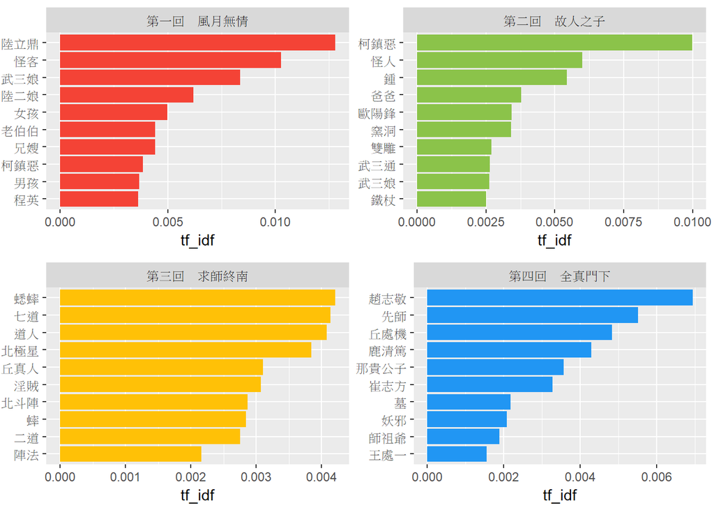

```r
G_E_C_1    <- split(G_E_C_word,G_E_C_word$chapter)
G_E_C_2 <- list()
for(r in 1:40){
  #挑出每一章tf_idf 值前10名的詞語
  G_E_C_2[[r]] <-  G_E_C_1[[r]][order(G_E_C_1[[r]]$tf_idf,decreasing = T)[1:10],]
}

my.color <- c("#2196F3","#F44336","#8BC34A","#FFC107")

my.g <- list()
for(r in 1:40){
g1  <- ggplot(G_E_C_2[[r]],aes(reorder(word,tf_idf),tf_idf))+geom_col(show.legend = FALSE,fill=my.color[(r%%4)+1])
my.g[[r]] <- g1+facet_wrap(~chapter, ncol = 2, scales = "free") + coord_flip()+labs(x=NULL,y="tf_idf")
}

r=1
ggarrange(my.g[[r*4-3]], my.g[[r*4-2]], my.g[[r*4-1]], my.g[[r*4]], ncol = 2, nrow = 2)
```

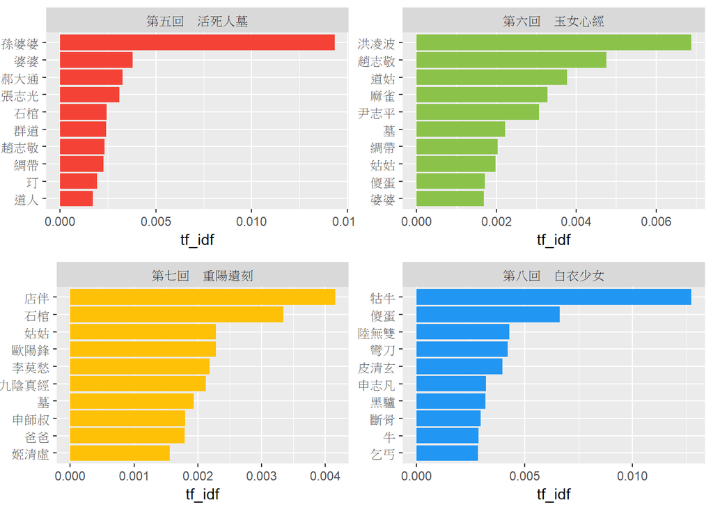

```r
r=2
ggarrange(my.g[[r*4-3]], my.g[[r*4-2]], my.g[[r*4-1]], my.g[[r*4]], ncol = 2, nrow = 2)
```

# 3. correlation and network

## correlation

```r
rm(list=ls())
library(jiebaR)
#幫助我們算相關性。
library(tm)
#增加自己設定的停止詞
my.text <- worker(stop_word = "C:\\Users\\biostat1142\\Documents\\R\\win-library\\3.4\\jiebaRD\\dict\\stop_words_g_e_c.utf8",
                  user="C:\\Users\\biostat1142\\Documents\\R\\win-library\\3.4\\jiebaRD\\dict\\g_e_c.dict.utf8")
data1 <- read.csv("C:\\Users\\biostat1142\\Desktop\\text mining\\G_E_C.csv",stringsAsFactors=F)


G_E_C <- list()
for(r in 1:40){
  chapter <- data1[r,1]
  word   <- my.text[data1[r,2]]
  word_2 <- freq(word)
  #抓出出現超過20次的詞語
  word_3 <- word_2[word_2$freq>20,]
  G_E_C[[r]] <- data.frame(chapter,word_3$char,word_3$freq)
}
G_E_C <- do.call(rbind,G_E_C)
colnames(G_E_C) <- c("chapter","word","n")

#把資料轉成DocumentTermMatrix
my.dtm <-  cast_dtm(G_E_C,chapter,word, n)
inspect(my.dtm[1:10,1:10])
```

```
## <<DocumentTermMatrix (documents: 10, terms: 10)>>
## Non-/sparse entries: 21/79
## Sparsity           : 79%
## Maximal term length: 3
## Weighting          : term frequency (tf)
## Sample             :
##                   Terms
## Docs               女孩 夫婦 李莫愁 怪客 武三娘 武修文 柯鎮惡 陸立鼎
##   第一回　風月無情   22   25     25   41     37     35     22     51
##   第七回　重陽遺刻    0    0     79    0      0      0      0      0
##   第九回　百計避敵    0    0     60    0      0      0      0      0
##   第二回　故人之子    0    0     57    0      0      0     74      0
##   第八回　白衣少女    0    0     43    0      0      0      0      0
##   第十回　少年英俠    0    0     80    0      0      0      0      0
##   第三回　求師終南    0    0      0    0      0     26      0      0
##   第五回　活死人墓    0    0      0    0      0      0      0      0
##   第六回　玉女心經    0    0     41    0      0      0      0      0
##   第四回　全真門下    0    0      0    0      0      0      0      0
##                   Terms
## Docs               陸無雙 程英
##   第一回　風月無情     50   48
##   第七回　重陽遺刻      0    0
##   第九回　百計避敵    131    0
##   第二回　故人之子      0   28
##   第八回　白衣少女    126    0
##   第十回　少年英俠      0    0
##   第三回　求師終南      0    0
##   第五回　活死人墓      0    0
##   第六回　玉女心經      0    0
##   第四回　全真門下      0    0
```

```r
data_cor1 <- findAssocs(my.dtm, c("楊過","小龍女","李莫愁","金輪法王","道士"), 0.3)
data_cor1[1]
```

```
## $楊過
##   師父   武功   姑姑 洪凌波   老婦   哥哥     掌 黑龍潭   瑛姑   靈狐
##   0.43   0.40   0.37   0.33   0.33   0.33   0.33   0.33   0.33   0.33
```

## network

```r
#資料轉換
data_cor <- list()
for(r in 1:5){
  x <- names(data_cor1[r])
  y <- names(data_cor1[[r]])
  cor <- data_cor1[[r]]
  data_cor[[r]] <- data.frame(x,y,cor)
}
data_cor <- do.call(rbind,data_cor)
data_cor[1:10,]
```

```
##           x      y  cor
## 師父   楊過   師父 0.43
## 武功   楊過   武功 0.40
## 姑姑   楊過   姑姑 0.37
## 洪凌波 楊過 洪凌波 0.33
## 老婦   楊過   老婦 0.33
## 哥哥   楊過   哥哥 0.33
## 掌     楊過     掌 0.33
## 黑龍潭 楊過 黑龍潭 0.33
## 瑛姑   楊過   瑛姑 0.33
## 靈狐   楊過   靈狐 0.33
```

```r
#畫network 圖的package
library(igraph)
library(ggraph)

#轉換成可以畫network 的資料型態
data_cor_network <- graph_from_data_frame(data_cor,directed = FALSE)
data_cor_network
```

```
## IGRAPH 28c31a6 UN-- 65 69 --
## + attr: name (v/c), cor (e/n)
## + edges from 28c31a6 (vertex names):
##  [1] 楊過    --師父     楊過    --武功     楊過    --姑姑
##  [4] 楊過    --洪凌波   楊過    --老婦     楊過    --哥哥
##  [7] 楊過    --掌       楊過    --黑龍潭   楊過    --瑛姑
## [10] 楊過    --靈狐     小龍女  --姑姑     小龍女  --咱們
## [13] 小龍女  --九陰真經 小龍女  --店伴     小龍女  --殺
## [16] 小龍女  --麻雀     小龍女  --道姑     小龍女  --劍
## [19] 小龍女  --師父     小龍女  --全真教   小龍女  --婆婆
## [22] 小龍女  --孫婆婆   小龍女  --捉       小龍女  --郝大通
## + ... omitted several edges
```

```
## Using `nicely` as default layout
```

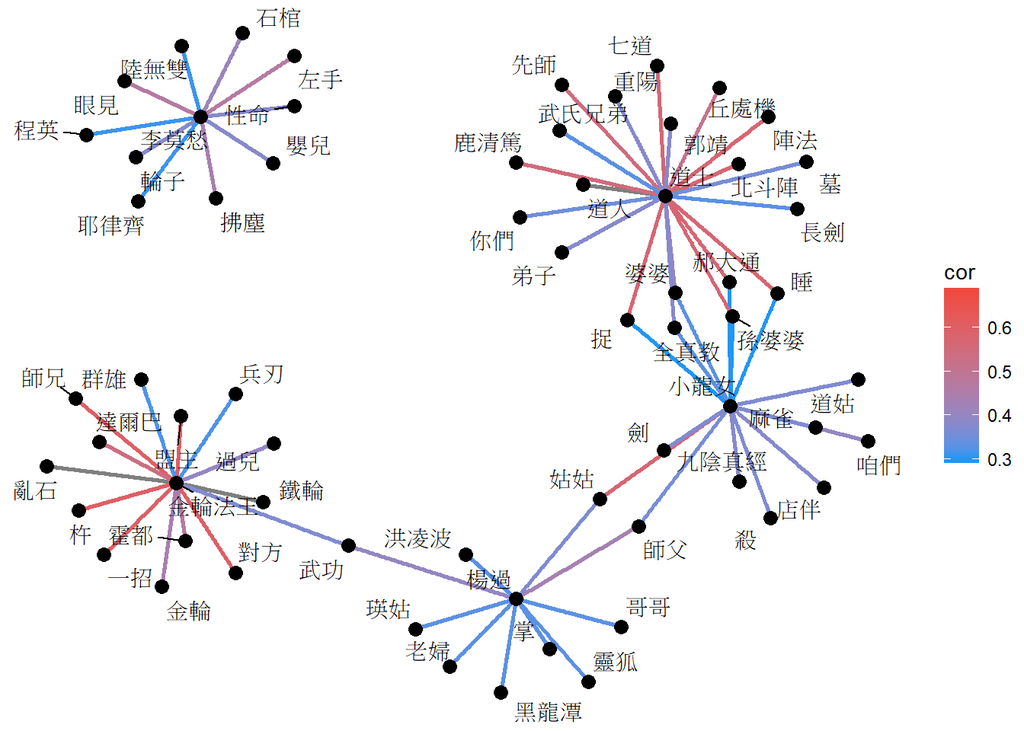

```r
ggraph(data_cor_network) +
  geom_edge_link(aes(edge_colour=cor),edge_width=1) +
  scale_edge_colour_gradient(limits = c(0.3, 0.7), low = "#2196F3", high = "#F44336") +
  geom_node_point(size=3) +
  geom_node_text(aes(label = name),repel=T,point.padding=unit(0.2,"lines"))+theme_void()
```

```
## Using `nicely` as default layout
```

[figure not shown]

```r
data_1 <- findAssocs(my.dtm, c("楊過"), 0)
x <- names(data_1[1])
y <- names(data_1[[1]])
cor <- data_1[[1]]
data_cor <- data.frame(x,y,cor)
data_cor1 <- data_cor[data_cor$y%in%c("小龍女","敵軍"),]

#設定位置
nodes <- c("楊過","小龍女","敵軍")
x <- c(-10,1,1)
y <- c(0,3.5,-3.5)
NodeList <- data.frame(nodes, x ,y)


data_cor2 <- graph_from_data_frame(data_cor1,vertices = NodeList,directed = FALSE)


ggraph(data_cor2) +
  #curvature 調整彎曲幅度與方向
  geom_edge_arc(aes(edge_colour=cor,edge_width=cor),arrow = arrow(length = unit(4, 'mm'),type="closed"),curvature=c(0.6,-0.6))+
  scale_edge_width(range = c(0.2,2),guide = 'none')+
  scale_edge_colour_gradient(limits = c(0, 0.5), low = "#2196F3", high = "#F44336") +
  geom_node_point(size=5) +
  geom_node_text(aes(label = name),repel=T,point.padding=unit(0.2,"lines"))+coord_fixed()+theme_void()
```

# 4. clustering

## 階層式分群(Hierarchical Clustering)

距離:

1. 歐式距離 :
   $$\sqrt{\sum\limits_{i=1}^{n}(x_i-y_i)^2}$$
2. 曼哈頓距離 :
   $$\sum_{i=1}^n|x_i-yi|$$

```r
my.dtm_2 <-  removeSparseTerms(my.dtm, sparse=0.9)
m  <- as.matrix(my.dtm_2)
m[1:10,1:10]
```

```
##                   Terms
## Docs               李莫愁 武修文 陸無雙 程英 郭芙 郭靖 黃蓉 楊過 他們 武功
##   第一回　風月無情     25     35     50   48    0    0    0    0    0    0
##   第二回　故人之子     57      0      0   28   31   76   71   80    0    0
##   第三回　求師終南      0     26      0    0   35  207   50  142   22   38
##   第四回　全真門下      0      0      0    0    0  116    0  154    0   39
##   第五回　活死人墓      0      0      0    0    0    0    0  214    0    0
##   第六回　玉女心經     41      0      0    0    0    0    0  266    0   44
##   第七回　重陽遺刻     79      0      0    0    0    0    0  219    0   29
##   第八回　白衣少女     43      0    126    0    0    0    0  183    0    0
##   第九回　百計避敵     60      0    131    0    0    0    0  247    0   32
##   第十回　少年英俠     80      0      0    0    0    0    0  208    0   34
```

```r
#dis 算距離矩陣
#歐式距離
dist_e <- dist(t(m), method="euclidean")
as.matrix(dist_e)[1:10,1:10]
```

```
##          李莫愁    武修文   陸無雙      程英     郭芙     郭靖     黃蓉
## 李莫愁   0.0000  264.5751 250.3318  229.8913 273.6220 442.4873 309.5868
## 武修文 264.5751    0.0000 217.0346  125.3076 208.1370 398.8671 322.9087
## 陸無雙 250.3318  217.0346   0.0000  186.2149 278.7956 461.0434 364.0137
## 程英   229.8913  125.3076 186.2149    0.0000 215.9884 420.4319 309.5836
## 郭芙   273.6220  208.1370 278.7956  215.9884   0.0000 388.6875 228.7466
## 郭靖   442.4873  398.8671 461.0434  420.4319 388.6875   0.0000 389.7037
## 黃蓉   309.5868  322.9087 364.0137  309.5836 228.7466 389.7037   0.0000
## 楊過   915.0945 1036.3870 986.4340 1021.8542 994.9407 944.7015 926.2516
## 他們   252.1289   83.2286 218.1124  126.6136 199.2887 388.5975 312.9680
## 武功   252.7608  155.6856 241.5450  187.4513 223.2241 374.3114 304.2729
##             楊過      他們     武功
## 李莫愁  915.0945  252.1289 252.7608
## 武修文 1036.3870   83.2286 155.6856
## 陸無雙  986.4340  218.1124 241.5450
## 程英   1021.8542  126.6136 187.4513
## 郭芙    994.9407  199.2887 223.2241
## 郭靖    944.7015  388.5975 374.3114
## 黃蓉    926.2516  312.9680 304.2729
## 楊過      0.0000 1034.3041 942.8361
## 他們   1034.3041    0.0000 144.5510
## 武功    942.8361  144.5510   0.0000
```

```r
#曼哈頓距離
dist_m <- dist(t(m), method="manhattan")
```

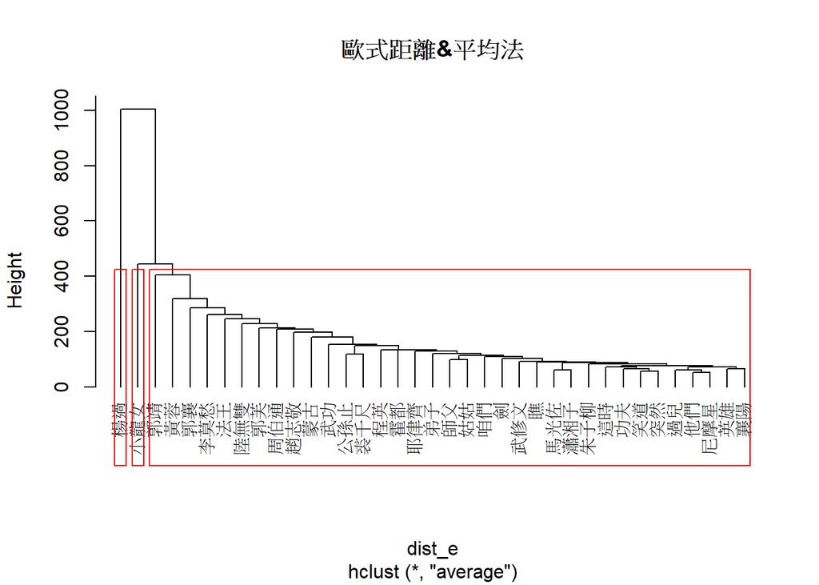

```r
#歐式距離&平均法
groups <- hclust(dist_e,method="average")
plot(groups, cex=0.9, hang=-1,main="歐式距離&平均法")
rect.hclust(groups, k=3)
```

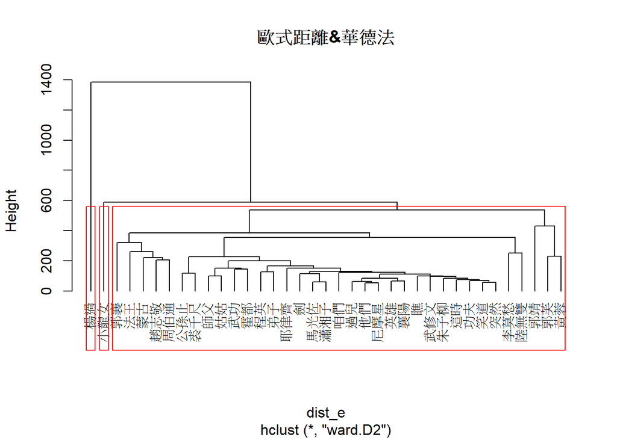

```r
#歐式距離&華德法
groups <- hclust(dist_e,method="ward.D2")
plot(groups, cex=0.9, hang=-1,main="歐式距離&華德法")
rect.hclust(groups, k=3)
```

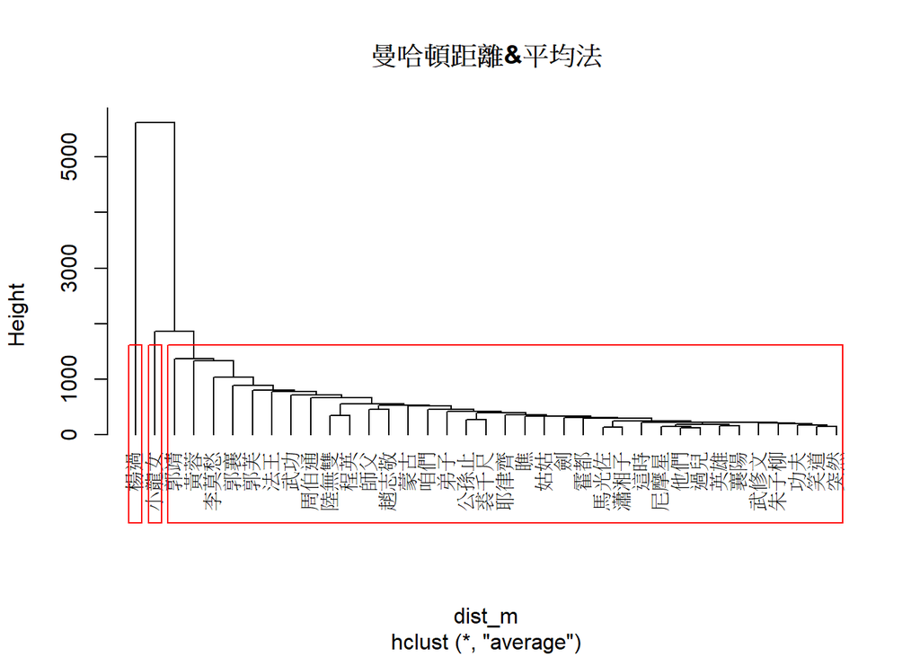

```r
#曼哈頓距離&平均法
groups <- hclust(dist_m,method="average")
plot(groups, cex=0.9, hang=-1,main="曼哈頓距離&平均法")
rect.hclust(groups, k=3)
```

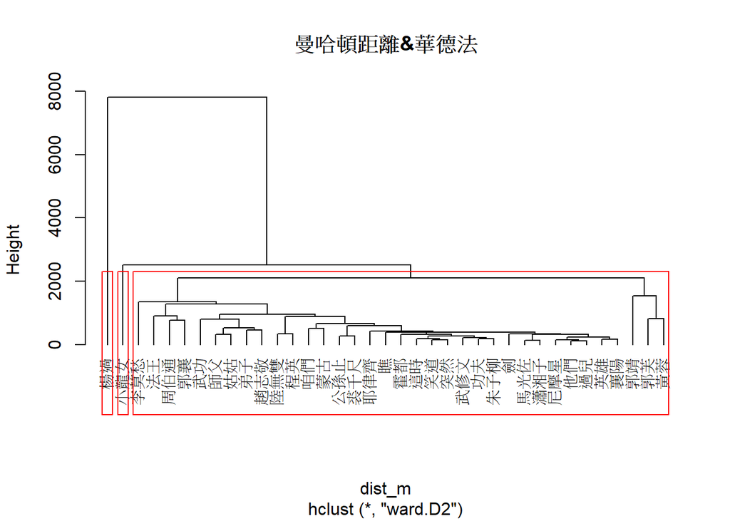

```r
#曼哈頓距離&華德法
groups <- hclust(dist_m,method="ward.D2")
plot(groups, cex=0.9, hang=-1,main="曼哈頓距離&華德法")
rect.hclust(groups, k=3)
```

## kmean

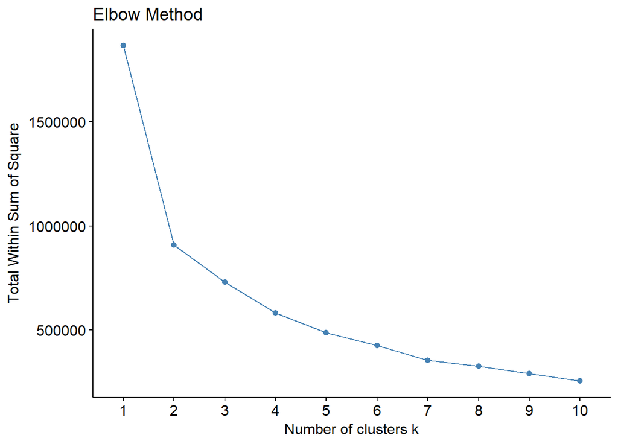

```r
library(ggplot2)
library(factoextra)
library(cluster)
#Elbow Method(群內變異最小)
fviz_nbclust(t(m), kmeans, method = "wss")+labs(title="Elbow Method")
```

側影系數(Silhouette Coefficient)

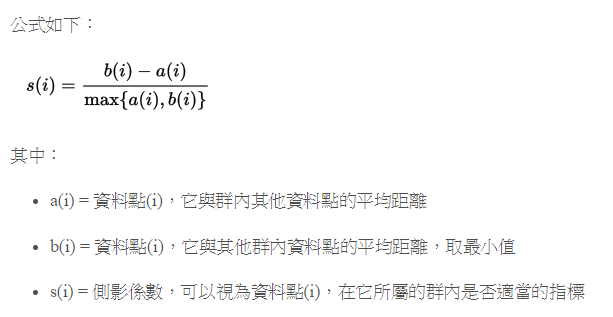

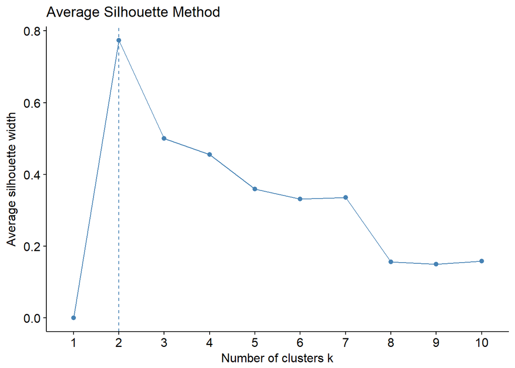

```r
#Average Silhouette Method
fviz_nbclust(t(m), kmeans, method = "silhouette")+labs(title="Average Silhouette Method")
```

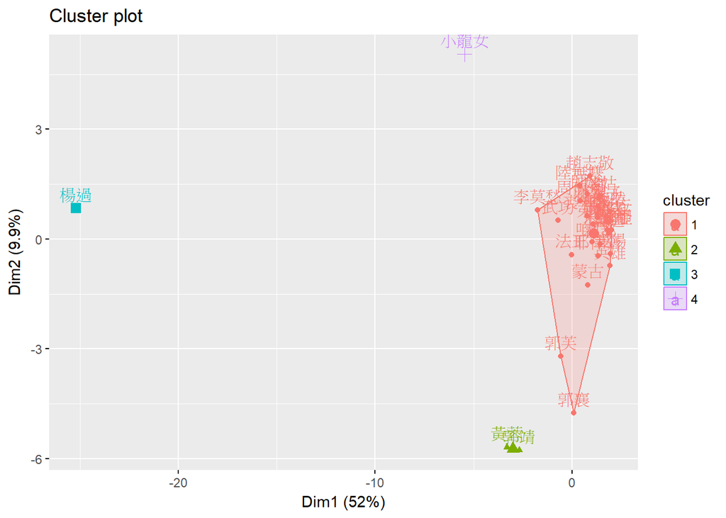

```r
#plot final
kmeans.cluster <- kmeans(t(m), centers=4,nstart = 25)
fviz_cluster(kmeans.cluster,data = t(m),geom = c("point","text"))
```

## dbscan

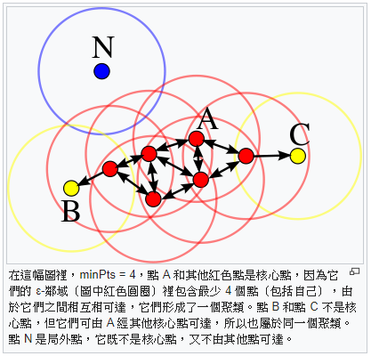

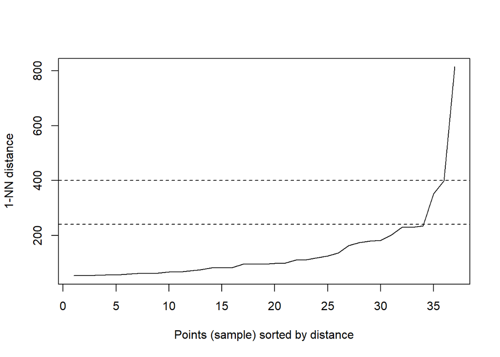

```r
library(dbscan)
kNNdistplot(t(m), k =  1)
abline(h = 400, lty = 2)
abline(h = 240, lty = 2)
```

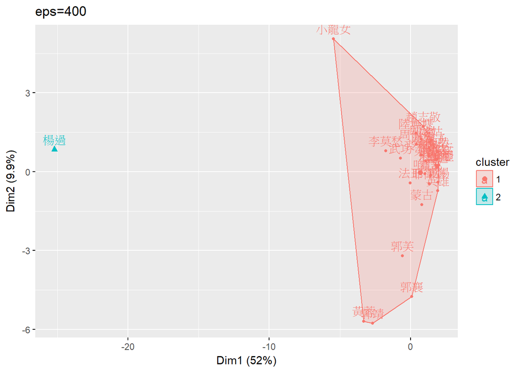

```r
db <- dbscan(t(m), eps = 400,minPts = 1) #minPts 最小分群數
fviz_cluster(db, t(m), geom = c("point","text"),pointsize = 1)+labs(title="eps=400")
```

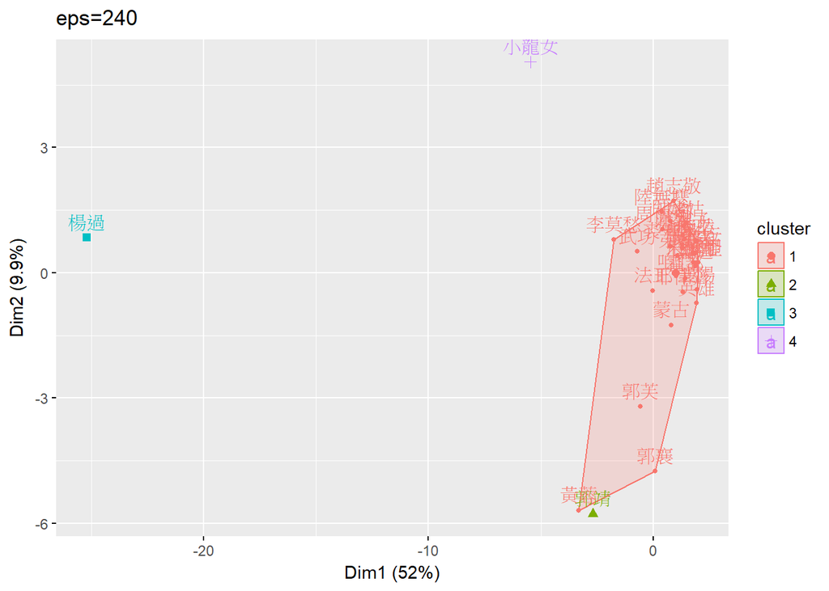

```r
db <- dbscan(t(m), eps = 240,minPts = 1) #minPts 最小分群數
fviz_cluster(db, t(m), geom = c("point","text"),pointsize = 1)+labs(title="eps=240")
```

# 參考資料

## text mining

1. https://www.tidytextmining.com/tidytext.html
2. http://rstudio-pubs-static.s3.amazonaws.com/12422_b2b48bb2da7942acaca5ace45bd8c60c.html
3. http://steve-chen.tw/?p=654

## clustering

1. https://rpubs.com/skydome20/R-Note9-Clustering
2. https://uc-r.github.io/kmeans_clustering